# Skoki narciarskie mężczyzn 2013/14 - EDA

Paweł Szulik

2026-04-07

# 1 Sekcja pakietów

```r
library(tidyverse)
library(dplyr)
library(stringr)
library(psych)
library(ggplot2)
library(corrplot)
```

# 2 Wprowadzenie

Podjąłem się analizy zbioru danych o skokach narciarskich. Oryginalny zbiór danych został pobrany ze strony Kaggle: (https://www.kaggle.com/datasets/wrotki8778/ski-jumping-results-database-2009now). Złożony jest z 5 podzbiorów, (ja na potrzeby mojej analizy będę korzystał tylko z 4, bez `all_ratings`) z których osobno zbyt wiele by nie wynikało, dlatego na potrzeby analizy, zanim jeszcze zacznę opisywać zmienne, muszę utworzyć jeden ostateczny zbiór, który będzie połączeniem wszystkich podzbiorów.

# 3 Przygotowanie danych

## 3.1 Łączenie zbiorów

Na 4 podzbiory składają się: `konkursy` - zawiera dane o wszystkich rozegranych konkursach z 2009-2021, `skoczkowie`- zawiera dane o wszystkich skoczkach z tego okresu `wyniki` - zawiera dane o wszystkich zarejestrowanych wynikach skoków z tego okresu, `statystyki` - zawiera statystyki pogodowe każdego z konkursów.

```r
konkursy   <- read.csv("all_comps.csv")
skoczkowie <- read.csv("all_names.csv")
wyniki     <- read.csv("all_results.csv")
statystyki <- read.csv("all_stats.csv")
```

Swoją analizę będę chciał przeprowadzić, na okrojonych danych, gdyż oryginalny zbiór danych jest zbyt duży. Będę pracował na danych za sezon zimowy 2013/14 mężczyzn. Sezon ten rozpoczął się 22.11.2013r., a skończył się 23.03.2014r. Wstępnie filtruję dane o konkursach. Moim celem jest zobaczenie, czy uzyskam informacje o skokach ze wszystkich interesujących mnie konkursów, treningów i serii próbnych - ostateczne dane i tak będą musiały zostać ponownie przefiltrowane, to filtrowanie jest czysto poglądowe, mogłoby zostać pominięte.

```r
konkursy_przefiltrowane <- konkursy %>%
  filter(season == "2014", date >= "2013-11-22")
```

W tabeli o skoczkach zauważam pierwszy problem, autor danych zescrapował je w taki sposób, że część skoczków się zduplikowała(rekordy różnią się literą, ale to jest ta sama osoba), przez co występują dwie osoby o takim samym codexie (id_skoczka). Pozbywamy się duplikatów codexów, jednocześnie zostawiamy przypisane im imiona i nazwiska skoczków.

```r
skoczkowie <- skoczkowie %>%
  arrange(codex)

head(skoczkowie, 5)
```

```
##               name codex
## 1          li yang  1900
## 2    tian zhandong  1901
## 3   korolev alexey  1905
## 4     korolev alex  1905
## 5 karpenko nikolay  1906
```

```r
skoczkowie %>%
  count(codex) %>%
  filter(n>1) %>%
  summarise(liczba_przypadkow = n())
```

```
##   liczba_przypadkow
## 1                75
```

```r
skoczkowie_unikatowi <- skoczkowie %>%
  distinct(codex, .keep_all = TRUE)

skoczkowie_unikatowi %>%
  count(codex) %>%
  filter(n>1) %>%
  summarise(liczba_przypadkow = n())
```

```
##   liczba_przypadkow
## 1                 0
```

Dalej mamy tabele statystyk i wyników, znajdujemy w nich następujące problemy: w tabeli statystyki trzeba zmienic nazwy kolumn, aby mozna bylo polaczyc, po kluczach z pozostałymi tabelami. Naszym kluczem bedzie tez round, dlatego sprawdzamy, czy nie trzeba tam czegos pozmieniac, w danych. Jest OK.

```r
head(statystyki, 3)
```

```
##          fis_code humid snow  air   weather_type   round_type max_wind avg_wind
## 1 2015JP3765RTRIA    70   NA 11.0 partly cloudy  trial round      2.06     0.82
## 2    2015JP3765RL    70   NA 11.2         sunny    1st round      0.90     0.09
## 3    2015JP3765RL    70   NA 11.4         sunny  final round      0.74     0.04
##   min_wind gate counted_jumpers all_jumpers all_countries
## 1    -0.13   18              50          50            14
## 2    -0.52   20              49          50            14
## 3    -0.55   24              30          30            12
```

```r
head(wyniki, 3)
```

```
##   points speed  dist dist_points note_1 note_2 note_3 note_4 note_5 note_points
## 1  137.8  91.9 131.0        79.8     19   19.5   19.0   19.5   19.5          58
## 2  132.3  91.3 128.5        75.3     19   19.0   18.5   19.5   19.0          57
## 3  131.4  91.1 128.0        74.4     19   19.0   19.0   19.0   18.0          57
##   gate            id loc bib round wind wind_comp gate_points Unnamed..0 codex
## 1   13 2009JP3007RLQ  NA             NA        NA          NA         NA  2088
## 2   13 2009JP3007RLQ  NA             NA        NA          NA         NA  4889
## 3   13 2009JP3007RLQ  NA             NA        NA          NA         NA  2067
```

```r
table(statystyki$round_type)
```

```
##
##     1st round      2nd round      3rd round    final round       prologue
##           2081           1195             50            827              7
## qualification     training 1     training 2     training 3    trial round
##            533            399            224             26           1147
```

```r
table(wyniki$round)
```

```
##
##                    1st round      2nd round      3rd round    final round
##           9898         101320          43623           1683          25274
##      prologue  qualification     training 1     training 2    trial round
##            312          29284          15697           7834          53087
```

```r
statystyki <- statystyki %>%
  rename(id = fis_code, round = round_type)
```

Wszystkie tabele wydają się w porządku, teraz pora je połączyć. Wynikom przypisuję skoczków po codexie (id_skoczka). Do tej tabeli dołączam dane o konkursach, po id (konkursu). Do utworzonej tabeli dołączam dane o statystykach konkursów i mam ostateczną tabelę: `ostateczne_dane`, na podstawie której będę prowadził swoją analizę. Dodatkowo, przefiltruję już wstepnie dane, aby brać pod uwagę, tylko sezon zimowy mężczyzn 2013/14.

```r
wyn_sko <- left_join(wyniki, skoczkowie_unikatowi,by = "codex")

wyn_sko_kon <- left_join(wyn_sko, konkursy_przefiltrowane, by = "id")

ostateczne_dane <- left_join(wyn_sko_kon, statystyki, by = c("id", "round"))

ostateczne_dane <- ostateczne_dane %>%
  filter(date >= "2013-11-22", gender == "Men")
```

## 3.2 Opis zmiennych

Wybiorę teraz zmienne, które w mojej opinii będą istotne dla mojej analizy. Odrzucam te, które będą niepotrzebne. Zmieniam też nazwy zmiennych, aby ułatwić analizę. Ustawiam dane według daty - od najwcześniejszych skoków w sezonie, po najpóźniejsze.

```r
ostateczne_dane <- ostateczne_dane %>%
  select(date, id, team, place, hill_size_x, k.point, round, training, codex.x, bib, name, dist, speed, points, note_points, wind, wind_comp, gate.x, gate.y, gate_points, humid, snow, air, weather_type) %>%
  rename(competition_id = id, location = place, hill_size=hill_size_x, skijumper_id=codex.x, points_overall=points, wind_compensation=wind_comp, jump_gate=gate.x, competition_start_gate=gate.y, starting_number=bib, air_temperature=air, snow_temperature=snow) %>%
  arrange(date)
```

- `date` - data konkursu
- `competition_id` - id konkursu
- `team`- czy konkurs byl druzynowy czy nie (0 - nie, 1 - tak)
- `location`- miejscowosc, w ktorej rozgrywany byl konkurs
- `hill_size` - rozmiar skoczni
- `k_point` - punkt konkstrukcyjny skoczni
- `round` - numer i typ rundy
- `training` - czy skok byl treningiem (0 - nie, 1 - tak)
- `ski_jumper_id` - id skoczka
- `starting_number` - numer startowy skoczka
- `dist` - odległość skoku mierzona w m
- `speed` - prędkość na progu w km/h
- `points` - punkty za skok
- `note_points` - punkty za notę
- `wind` - predkosc wiatru w m/s (>0 - wiatr pod narty, <0 - wiatr w plecy)
- `wind_comp` - rekompensata za wiatr
- `jump_gate` - belka startowa skoku
- `competition_start_gate` - belka z ktorej rozpoczal sie konkurs
- `starting_number` - numer startowy skoczka
- `humid` - wilgotność powietrza (0-100%)
- `snow_temprature` - temperatura śniegu na podjeździe (w Celsjuszach)
- `air_temperature` - temperatura powietrza (w Celsjuszach)
- `weather type` - ogólny typ pogody panujący w trakcie konkursu

## 3.3 Filtrowanie danych

Patrzę teraz na strukturę przygotowanego już pliku.

```r
str(ostateczne_dane)
```

```
## 'data.frame':    14134 obs. of  24 variables:
##  $ date                  : chr  "2013-11-22" "2013-11-22" "2013-11-22" "2013-11-22" ...
##  $ competition_id        : chr  "2014JP3827RLQ" "2014JP3827RLQ" "2014JP3827RLQ" "2014JP3827RLQ" ...
##  $ team                  : int  0 0 0 0 0 0 0 0 0 0 ...
##  $ location              : chr  "Klingenthal (GER)" "Klingenthal (GER)" "Klingenthal (GER)" "Klingenthal (GER)" ...
##  $ hill_size             : num  140 140 140 140 140 140 140 140 140 140 ...
##  $ k.point               : num  125 125 125 125 125 125 125 125 125 125 ...
##  $ round                 : chr  "qualification " "qualification " "qualification " "qualification " ...
##  $ training              : int  0 0 0 0 0 0 0 0 0 0 ...
##  $ skijumper_id          : num  4325 5972 5142 4141 5429 ...
##  $ starting_number       : chr  "63" "53" "45" "61" ...
##  $ name                  : chr  "zyla piotr" "fannemel anders" "kubacki dawid" "kofler andreas" ...
##  $ dist                  : num  138 138 136 138 136 ...
##  $ speed                 : num  92 92.3 93.2 92.8 92.8 92.8 91.9 93.1 93.3 91.6 ...
##  $ points_overall        : num  128 127 126 125 125 ...
##  $ note_points           : num  56.5 57 55.5 55.5 54.5 55.5 55.5 55 54.5 55.5 ...
##  $ wind                  : num  0.35 0.64 0.1 0.64 0.24 -0.08 0.65 0.22 -0.11 0.88 ...
##  $ wind_compensation     : num  -3.8 -6.9 -1.1 -6.9 -2.6 1 -7 -2.4 1.4 -9.5 ...
##  $ jump_gate             : num  26 26 26 26 26 26 25 26 26 25 ...
##  $ competition_start_gate: num  24 24 24 24 24 24 24 24 24 24 ...
##  $ gate_points           : num  -6.8 -6.8 -6.8 -6.8 -6.8 -6.8 -3.4 -6.8 -6.8 -3.4 ...
##  $ humid                 : num  92 92 92 92 92 92 92 92 92 92 ...
##  $ snow_temperature      : num  -6.5 -6.5 -6.5 -6.5 -6.5 -6.5 -6.5 -6.5 -6.5 -6.5 ...
##  $ air_temperature       : num  3.5 3.5 3.5 3.5 3.5 3.5 3.5 3.5 3.5 3.5 ...
##  $ weather_type          : chr  "overcast " "overcast " "overcast " "overcast " ...
```

Kolejną rzeczą, jaką chcę zrobić, to przekształcić zmienne kategoryczne na factory i zmienną `date` na format date, bo jest obecnie jako character. Sprawdzam strukturę potencjalnych zmiennych kategorycznych. Przy zmiennej weather_type uzywam funkcji `str_trim()`, zeby naprawic dane, ktore mają te same wartosci, ale sa liczone osobno, bo jest spacja np. sunny i cloudy. Zmienna team daje jako factor osobno, dodaje levels. Dla zmiennej round mam problem - wartości 2nd round i final round są rozdzielone + final round jest zapisane na wiele sposobów (dane ze spacjami - używam `str_trim()`), ale oznaczają to samo. Zamieniam wartości final round na 2nd round, aby ujednolicić dane.

```r
table(ostateczne_dane$weather_type)
```

```
##
##                          brief rain and snowfall                     clear
##                       30                       61                       90
##                   clear                    cloudy                  cloudy
##                      720                      480                     1932
##           cloudy / rain           cloudy to rainy          cloudy to snowy
##                      100                       54                       29
##          cloudy to sunny     cloudy, rainy, snowy             cloudy/rainy
##                       56                       54                       52
##                     fog             lightly rain            mostly cloudy
##                      102                      254                       50
##                 overcast                overcast         overcast to snowy
##                     1942                     1155                      151
##          overcast, rainy            partly cloudy           partly cloudy
##                       30                      920                     1381
##                    rain                     rainy              rainy/snowy
##                      204                      274                       71
##                snowfall        snowfall / cloudy                     snowy
##                      616                       50                      459
##           snowy to sunny                    sunny                   sunny
##                       30                     1262                     1037
##     sunny, cloudy, snowy
##                       31
```

```r
table(ostateczne_dane$location)
```

```
##
##            Bischofshofen (AUT)          Brattleboro, VT (USA)
##                            338                            206
##               Brotterode (GER)               Courchevel (FRA)
##                            509                            552
##                Engelberg (SUI)                    Falun (SWE)
##                            875                            563
##   Garmisch-Partenkirchen (GER)                Harrachov (CZE)
##                            298                            264
##                Innsbruck (AUT)        Iron Mountain, MI (USA)
##                            321                            358
##              Klingenthal (GER)                   Kuopio (FIN)
##                            373                            202
##                    Lahti (FIN)              Lillehammer (NOR)
##                           1008                            490
##             Nizhny Tagil (RUS)                 Notodden (NOR)
##                            191                            332
##               Oberstdorf (GER)                     Oslo (NOR)
##                            489                            247
##                  Planica (SLO)                 Predazzo (ITA)
##                            563                            471
##                   Rasnov (ROU)                     Rena (NOR)
##                            277                            498
##                     Ruka (FIN)                  Sapporo (JPN)
##                            220                           1080
##                  Seefeld (AUT) Tauplitz/Bad Mitterndorf (AUT)
##                            431                            402
##         Titisee-Neustadt (GER)                Trondheim (NOR)
##                            459                            313
##                Willingen (GER)                    Wisla (POL)
##                            375                            300
##                 Zakopane (POL)
##                           1129
```

```r
table(ostateczne_dane$round)
```

```
##
##                    1st round      2nd round    final round  qualification
##            457           5106           2294           1022           1647
##    training 1     training 2    trial round
##            790            672           2146
```

```r
table(ostateczne_dane$team)
```

```
##
##     0     1
## 13587   547
```

```r
table(ostateczne_dane$training)
```

```
##
##    0    1
## 7296 6838
```

```r
ostateczne_dane <- ostateczne_dane %>%
  mutate(round=str_trim(round), round = if_else(round == "final round", "2nd round", round))

ostateczne_dane <- ostateczne_dane %>%
  mutate(date=as.Date(date), weather_type=as.factor(str_trim(weather_type)), location=as.factor(location),
         round=as.factor(round))

ostateczne_dane$team <- factor(ostateczne_dane$team, levels = c(0,1))

table(ostateczne_dane$round)
```

```
##
##                   1st round     2nd round qualification    training 1
##           457          5106          3316          1647           790
##    training 2   trial round
##           672          2146
```

Wyznaczam statystyki, `describe` tylko dla numerycznych, tam gdzie jest sens

```r
summary(ostateczne_dane)
```

```
##       date            competition_id     team                 location
##  Min.   :2013-11-22   Length:14134       0:13587   Zakopane (POL) :1129
##  1st Qu.:2013-12-27   Class :character   1:  547   Sapporo (JPN)  :1080
##  Median :2014-01-18   Mode  :character             Lahti (FIN)    :1008
##  Mean   :2014-01-23                                Engelberg (SUI): 875
##  3rd Qu.:2014-02-22                                Falun (SWE)    : 563
##  Max.   :2014-03-23                                Planica (SLO)  : 563
##                                                    (Other)        :8916
##    hill_size        k.point                round         training
##  Min.   : 96.0   Min.   : 88.0                : 457   Min.   :0.0000
##  1st Qu.:111.0   1st Qu.: 99.0   1st round    :5106   1st Qu.:0.0000
##  Median :134.0   Median :120.0   2nd round    :3316   Median :0.0000
##  Mean   :129.8   Mean   :116.6   qualification:1647   Mean   :0.4838
##  3rd Qu.:139.0   3rd Qu.:125.0   training 1   : 790   3rd Qu.:1.0000
##  Max.   :205.0   Max.   :185.0   training 2   : 672   Max.   :1.0000
##                                  trial round  :2146
##   skijumper_id  starting_number        name                dist
##  Min.   :1905   Length:14134       Length:14134       Min.   : 37.0
##  1st Qu.:4325   Class :character   Class :character   1st Qu.: 97.0
##  Median :5298   Mode  :character   Mode  :character   Median :115.0
##  Mean   :4986                                         Mean   :112.9
##  3rd Qu.:5939                                         3rd Qu.:125.0
##  Max.   :7317                                         Max.   :212.5
##
##      speed        points_overall   note_points         wind
##  Min.   :  0.00   Min.   :  1.1   Min.   :10.50   Min.   :-3.750
##  1st Qu.: 88.80   1st Qu.:101.4   1st Qu.:50.50   1st Qu.:-0.540
##  Median : 90.70   Median :114.8   Median :52.00   Median :-0.130
##  Mean   : 90.58   Mean   :112.6   Mean   :51.68   Mean   :-0.105
##  3rd Qu.: 92.80   3rd Qu.:125.4   3rd Qu.:54.00   3rd Qu.: 0.340
##  Max.   :101.50   Max.   :200.4   Max.   :59.00   Max.   : 3.800
##                   NA's   :6838    NA's   :6838    NA's   :1790
##  wind_compensation   jump_gate    competition_start_gate  gate_points
##  Min.   :-33.5     Min.   : 2.0   Min.   : 0.00          Min.   :-18.000
##  1st Qu.: -3.2     1st Qu.:12.0   1st Qu.:12.00          1st Qu.:  0.000
##  Median :  1.4     Median :15.0   Median :15.00          Median :  0.000
##  Mean   :  1.3     Mean   :15.9   Mean   :15.15          Mean   :  0.798
##  3rd Qu.:  5.9     3rd Qu.:19.0   3rd Qu.:18.00          3rd Qu.:  0.000
##  Max.   : 42.9     Max.   :32.0   Max.   :33.00          Max.   : 37.400
##  NA's   :1790      NA's   :1000   NA's   :1219           NA's   :3166
##      humid       snow_temperature  air_temperature          weather_type
##  Min.   :  0.0   Min.   :-12.000   Min.   :-15.000   overcast     :3097
##  1st Qu.: 69.0   1st Qu.: -7.900   1st Qu.: -1.000   cloudy       :2412
##  Median : 81.0   Median : -6.000   Median :  2.000   partly cloudy:2301
##  Mean   : 78.4   Mean   : -5.968   Mean   :  1.088   sunny        :2299
##  3rd Qu.: 90.0   3rd Qu.: -4.700   3rd Qu.:  4.000   clear        : 810
##  Max.   :100.0   Max.   : -1.000   Max.   : 14.500   (Other)      :2758
##  NA's   :487     NA's   :487       NA's   :487       NA's         : 457
```

```r
ostateczne_dane %>%
  select(dist, speed, points_overall, note_points, wind, wind_compensation, jump_gate, gate_points) %>%
  describe()
```

```
##                   vars     n   mean    sd median trimmed   mad    min   max
## dist                 1 14134 112.95 21.68 115.00  112.27 18.53  37.00 212.5
## speed                2 14134  90.58  4.41  90.70   90.67  2.97   0.00 101.5
## points_overall       3  7296 112.56 22.49 114.80  113.41 17.49   1.10 200.4
## note_points          4  7296  51.68  3.26  52.00   51.98  2.97  10.50  59.0
## wind                 5 12344  -0.10  0.77  -0.13   -0.11  0.65  -3.75   3.8
## wind_compensation    6 12344   1.30  7.57   1.40    1.37  6.67 -33.50  42.9
## jump_gate            7 13134  15.90  5.27  15.00   15.66  4.45   2.00  32.0
## gate_points          8 10968   0.80  5.60   0.00    0.42  0.00 -18.00  37.4
##                    range  skew kurtosis   se
## dist              175.50  0.63     1.83 0.18
## speed             101.50 -7.89   161.86 0.04
## points_overall    199.30 -0.41     2.42 0.26
## note_points        48.50 -2.68    19.38 0.04
## wind                7.55  0.13     1.20 0.01
## wind_compensation  76.40 -0.10     1.27 0.07
## jump_gate          30.00  0.41    -0.22 0.05
## gate_points        55.40  1.30     7.55 0.05
```

Zajmujemy się teraz brakami danych. Najwięcej braków danych mam w Punktach - to dosyć ważna zmienna, jednakże jest to prawdopodobnie spowodowane tym, że w seriach treningowych, punkty nie są liczone. Podejmuję decyzję, sprawdzam zależności związane z punktacją skoku, tylko dla skoków konkursowych.

```r
colSums(is.na(ostateczne_dane))
```

```
##                   date         competition_id                   team
##                      0                      0                      0
##               location              hill_size                k.point
##                      0                      0                      0
##                  round               training           skijumper_id
##                      0                      0                      0
##        starting_number                   name                   dist
##                      0                      0                      0
##                  speed         points_overall            note_points
##                      0                   6838                   6838
##                   wind      wind_compensation              jump_gate
##                   1790                   1790                   1000
## competition_start_gate            gate_points                  humid
##                   1219                   3166                    487
##       snow_temperature        air_temperature           weather_type
##                    487                    487                    457
```

```r
table(ostateczne_dane$training)
```

```
##
##    0    1
## 7296 6838
```

```r
ostateczne_dane <- ostateczne_dane %>%
  filter(training == 0, round!='qualification')

colSums(is.na(ostateczne_dane))
```

```
##                   date         competition_id                   team
##                      0                      0                      0
##               location              hill_size                k.point
##                      0                      0                      0
##                  round               training           skijumper_id
##                      0                      0                      0
##        starting_number                   name                   dist
##                      0                      0                      0
##                  speed         points_overall            note_points
##                      0                      0                      0
##                   wind      wind_compensation              jump_gate
##                   1000                   1000                   1000
## competition_start_gate            gate_points                  humid
##                     52                   1000                     30
##       snow_temperature        air_temperature           weather_type
##                     30                     30                      0
```

Mam ostatni problem z brakami - 1000 obserwacji, w których nie ma wartości przy wietrze, rekompensacie za wiatr, belce i punktach za belkę. Jest to spowodowane tym, że w sezonie 2013/14 FiS dopiero wprowadzał ideę punktów za wiatr i za belkę - wcześniej liczyła się tylko odległość i noty, dlatego niektóre konkursy nie zawierały takich danych. Na potrzeby mojej analizy, pominę te dane. Mam również, niewielką ilość braków w zmiennych `competition_start_gate`, `air_temperature`, `humid`, `snow_temperature`. Pomijam te dane, jest to bardzo niewielka część moich obserwacji - nie wpłynie to na zależności, które będę chciał pokazać.

```r
ostateczne_dane <- ostateczne_dane %>%
  filter(!is.na(wind)) %>%
  filter(!is.na(competition_start_gate)) %>%
  filter(!is.na(humid))

colSums(is.na(ostateczne_dane))
```

```
##                   date         competition_id                   team
##                      0                      0                      0
##               location              hill_size                k.point
##                      0                      0                      0
##                  round               training           skijumper_id
##                      0                      0                      0
##        starting_number                   name                   dist
##                      0                      0                      0
##                  speed         points_overall            note_points
##                      0                      0                      0
##                   wind      wind_compensation              jump_gate
##                      0                      0                      0
## competition_start_gate            gate_points                  humid
##                      0                      0                      0
##       snow_temperature        air_temperature           weather_type
##                      0                      0                      0
```

Pozbyliśmy się wszystkich braków. Możemy przejść do analizy.

# 4 Analiza danych

## 4.1 Zmienna dist_prop

Ze względu na niejednolite rozmiary skoczni, będę potrzebował zmiennej, która pozwoli mi badać długość skoku, nie jako odległość, ale jako proporcję uzyskanej odległości skoczka do punktu konstrukcyjnego skoczni `k.point`. Pozwoli mi to na uzyskanie sensownych i rzetelnych wyników teraz i w trakcie całej mojej analizy. Zmienna `dist_prop` będzie przyjmowała wartości: - mniejsze od 1 - co będzie oznaczało skok przed punktem k danej skoczni - większe od 1 - co będzie oznaczało skok za punkt k danej skoczni

```r
ostateczne_dane$dist_prop<-(ostateczne_dane$dist/ostateczne_dane$k.point)
```

## 4.2 Jak rozkłada się długość skoków?

Najpierw chcę dowiedzieć się jak wygląda rozkład skoków względem długości w całym sezonie 2013/14.

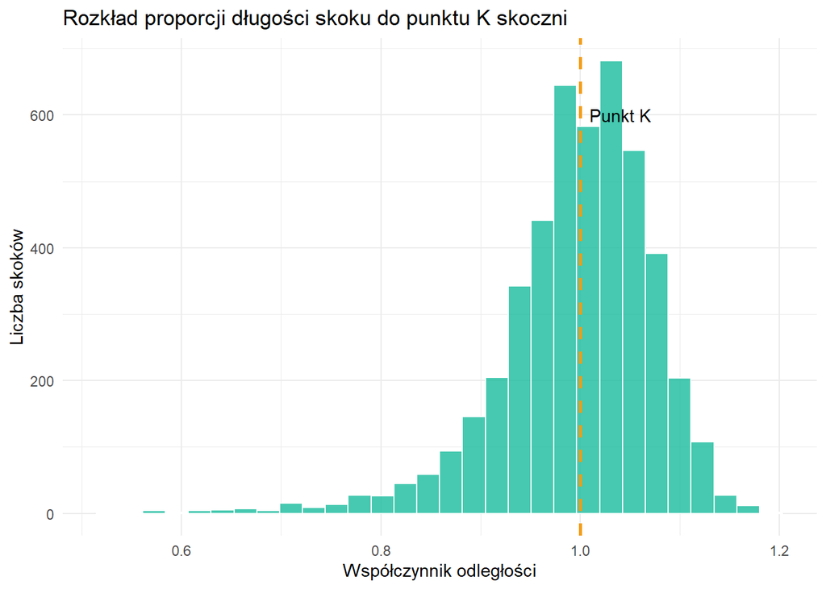

```r
ostateczne_dane %>%
  ggplot() +
  geom_histogram(mapping = aes(x=dist_prop), col='white', fill = '#18bc9c', bins =30, alpha = 0.8) +
  geom_vline(xintercept = 1, linetype="dashed", col='#f39c12', linewidth = 1) +
  annotate("text", x =1.04, y = 600, label = "Punkt K") +
  labs(title="Rozkład proporcji długości skoku do punktu K skoczni",
       x="Współczynnik odległości",
       y="Liczba skoków") +
  theme_minimal()
```

## 4.3 Jak rozkłada się długość skoków w zależności od serii konkursu?

W pierwszej serii konkursu skaczą wszyscy zakwalifikowani skoczkowie, w drugiej zostaje najlepsza trzydziestka. Można by założyć hipotezę, że skoczkowie z drugiej serii, powinni latać dalej, czy tak będzie naprawdę?

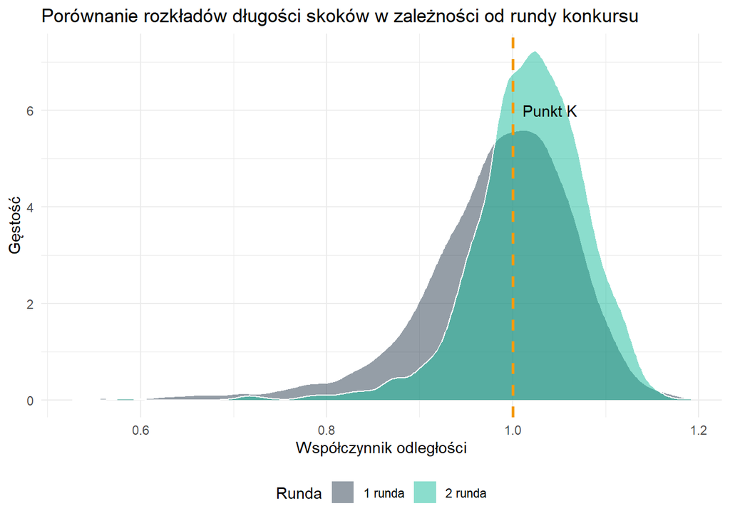

```r
kolory_wykresow <- c("1st round" = "#2c3e50", "2nd round" = "#18bc9c")

ostateczne_dane %>%
  ggplot() +
  geom_density(mapping = aes(x=dist_prop, fill = round), col= "white", alpha=0.5) +
  geom_vline(xintercept = 1, linetype="dashed", col='#f39c12', linewidth = 1) +
  annotate("text", x =1.04, y = 6, label = "Punkt K") +
  scale_fill_manual(
    values = kolory_wykresow,
    labels = c("1 runda", "2 runda")
    ) +
  labs(title="Porównanie rozkładów długości skoków w zależności od rundy konkursu",
       x="Współczynnik odległości",
       y="Gęstość",
       fill="Runda") +
  theme_minimal() +
  theme(legend.position = "bottom")
```

**wnioski:** Rozkład pozostaje podobny do ogólnego rozkładku skoków i faktycznie widzimy, że **skoczkowie w drugiej rundzie skaczą częściej za punkt k, w porównaniu do skoczków z 1 rundy**. Do drugiej serii awansuje najlepsza 30 zawodników z 1 etapu konkursu. Naturalnie wynika to z tego, że do 2 serii dostają się lepsi skoczkowie.

## 4.4 Czy typ konkursu wpływa na uzyskaną odległość skoku?

Długość skoku można jeszcze analizować pod względem typu konkursu. W skokach narciarskich na czas sezonu 2013/14 istniały dwa typy konkursów: indywidualne (każdy skacze dla siebie), drużynowe (skoczkowie skaczą w drużynach po 4 skoczków, na państwo). Czy skoczkowie będą dalej latać, wtedy kiedy skaczą dla siebie czy gdy skaczą dla drużyny?

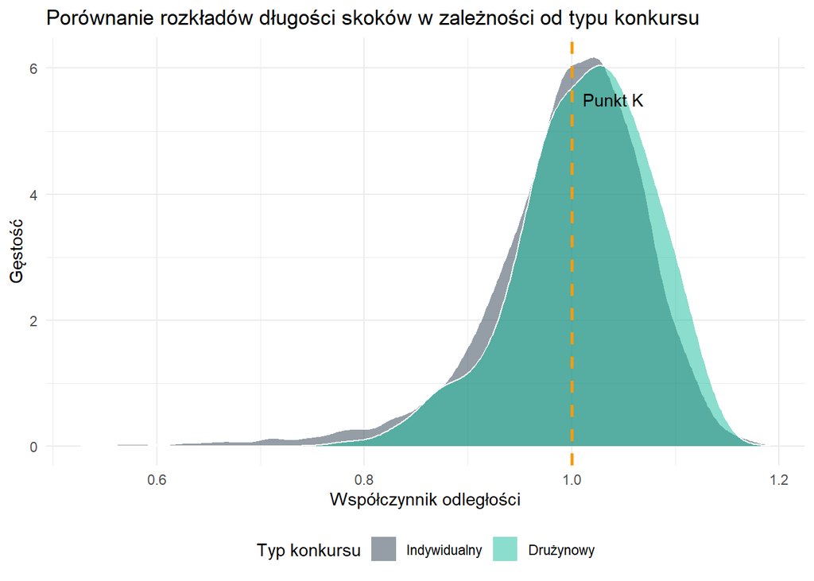

```r
kolory_wykresow <- c("0" = "#2c3e50", "1" = "#18bc9c")

ostateczne_dane %>%
  ggplot() +
  geom_density(mapping = aes(x=dist_prop, fill = team), col = "white", alpha=0.5) +
  geom_vline(xintercept = 1, linetype="dashed", col='#f39c12', linewidth = 1) +
  annotate("text", x =1.04, y = 5.5, label = "Punkt K") +
  scale_fill_manual(
    values = kolory_wykresow,
    labels = c("Indywidualny", "Drużynowy")
    ) +
  labs(title="Porównanie rozkładów długości skoków w zależności od typu konkursu",
       x="Współczynnik odległości",
       y="Gęstość",
       fill="Typ konkursu") +
  theme_minimal() +
  theme(legend.position = "bottom")
```

**wnioski:** Rozkłady są praktycznie identyczne - nie można zatem wnioskować, **że typ konkursu wpływa na odległość skoku uczestnika**. Widzimy zatem, że skoczkowie mają podobną motywację,

## 4.5 Na jakich skoczniach lata się najdalej?

Długość skoku można jeszcze analizować pod kątem miejscowości i konkretnej skoczni, na której skok został oddany. Interesowało mnie na których skoczniach zawodnicy radzą sobie lepiej, a na których już trochę gorzej.

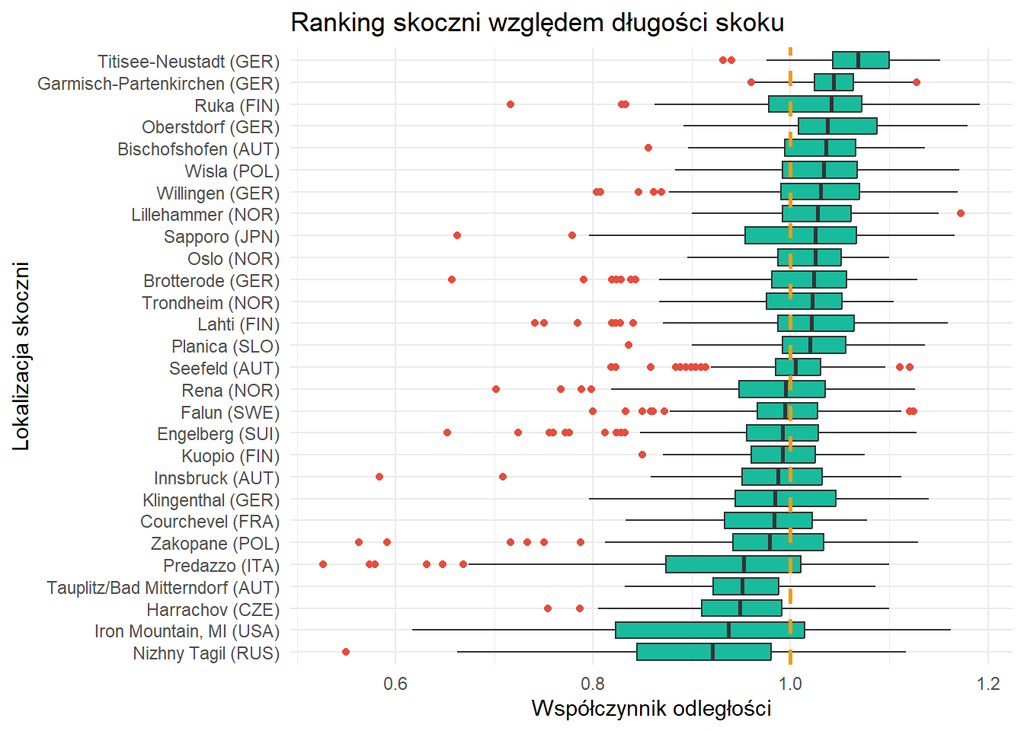

```r
ostateczne_dane %>%
  ggplot() +
  geom_boxplot(aes(x= reorder(location, dist_prop, FUN=median), y = dist_prop), fill="#18bc9c", outlier.color = "#e74c3c") +
  geom_hline(yintercept = 1, linetype="dashed", col='#f39c12', linewidth = 1) +
  labs(title="Ranking skoczni względem długości skoku",
       x="Lokalizacja skoczni",
       y="Współczynnik odległości") +
  coord_flip() +
  theme_minimal()
```

**wnioski:** Na podstawie wykresu można stwierdzić, że skoczkowie oddawali dłuższe skoki w **Garmisch-Partenkirchen i Titisee-Neustadt**. Natomiast krótsze skoki oddawane były w **Iron Mountain czy Nizhny Tagil**. Widzimy też, że tam gdzie zawodnicy latali dalej, wariancje długości oddanych prób są krótsze, rozrzut długości jest niewielki, natomiast tam gdzie skoczkowie przeciętnie latali krócej, już ten rozrzut jest znacznie większy, co pokazuje, że dla sportowców, technicznie są to cięższe skocznie. Możemy też zauważyć outliery, które będą symbolizować, przeważnie bardzo krótkie próby, lecz jest też kilka prób, gdzie skoczkowie wyróżnili się pod względem długości wobec konkurencji.

## 4.6 Jak na danej skoczni wygląda odsetek skoków oddanych poza jej rozmiar?

Ciekawiło mnie, na których skoczniach skoczkowie częściej oddają skoki poza jej rozmiar. Do tego pytania potrzebna będzie mi nowa zmienna, która będzie stwierdzać czy dany skok został oddany poza rozmiar skoczni czy nie. Po odpowiednim filtrowaniu, robię wykres.

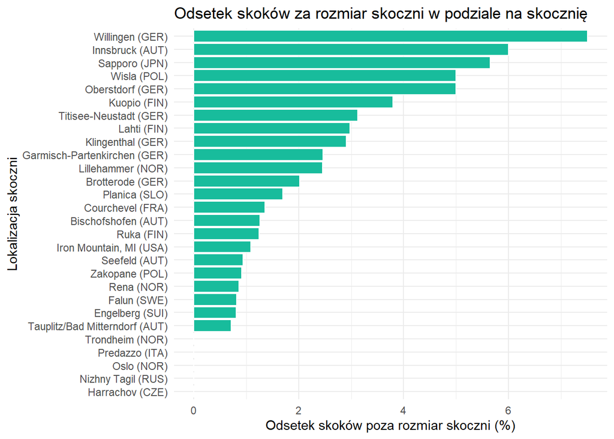

```r
ostateczne_dane <- ostateczne_dane %>%
  mutate(over_hs = dist > hill_size)

over_hs_ski_jump <- ostateczne_dane %>%
  group_by(location) %>%
  summarise(
    percent_over_hs = mean(over_hs) * 100) %>%
  arrange(desc(percent_over_hs))

over_hs_ski_jump %>%
  ggplot() +
  geom_col(aes(x = reorder(location, percent_over_hs), y = percent_over_hs), col = 'white', fill='#18bc9c') +
  coord_flip() +
   labs(
    title = "Odsetek skoków za rozmiar skoczni w podziale na skocznię",
    x = "Lokalizacja skoczni",
    y = "Odsetek skoków poza rozmiar skoczni (%)"
  ) +
  theme_minimal()
```

**wnioski:** Z wykresu możemy odczytać, że odsetek skoków poza rozmiar skoczni **najwyższy był w Willingen (7,5%) i w Innsbrucku (6%)**. A skocznie, na których w sezonie 2013/14 w ogóle **nie oddano skoków poza rozmiar skoczni (0%), to: Harrachov, Nizhny Tagil, Oslo, Predazzo, Trondheim**.

## 4.7 Którzy skoczkowie i ile razy latali za HS w sezonie 2013/14?

Wiemy już na których skoczniach skoczkowie najczęściej oddawali skoki poza HS. Teraz pytanie, który ze skoczków oddał ich najwięcej? Tak jak wcześniej, najpierw filtrowanie i grupowanie, potem wykres (pokazuję tylko skoczków, co mieli więcej niż jeden skok za rozmiar skoczni).

[figure not shown]

```r
over_hs_ski_jumpers<- ostateczne_dane %>%
  group_by(skijumper_id, name) %>%
  summarise(
    over_hs_jumps=sum(over_hs)
  ) %>%
  filter(over_hs_jumps > 1) %>%
  arrange(desc(over_hs_jumps))

over_hs_ski_jumpers %>%
  ggplot() +
  geom_col(aes (x = reorder(name, over_hs_jumps), y = over_hs_jumps), fill = "#18bc9c", col="white") +
  coord_flip() +
   scale_y_continuous(breaks = seq(0, max(over_hs_ski_jumpers$over_hs_jumps), by = 1)) +
  labs(
    title = "Zawodnicy z co najmniej jednym skokiem za rozmiar skoczni",
    x = "Zawodnik",
    y = "Ilość skoków za rozmiar skoczni"
  ) +
  theme_minimal()
```

**wnioski:** Widzimy, że najwięcej skoków za HS oddawali: **Peter Prevc, Kamil Stoch i Severin Freund**. Jest to trójka najlepszych zawodników pod względem punktacji w sezonie, z tym faktem, że Kamil Stoch wyprzedził Petera Prevca, który miał o jeden skok za rozmiar skoczni więcej. Widać, że ilość skoków za HS nie jest gwarancją wygranej w sezonie.

## 4.8 Jak pogoda wpływa na długość skoku?

Ciekawym aspektem może być zależność pomiędzy długością skoku, a pogodą panującą na skoczni. Wiadomo, że warunki atmosferyczne mają wpływ na skok, teraz pytanie jest, w jakiej pogodzie, skoczkowie oddawali dłuższe skoki, a które warunki powodowały krótszy wynik.

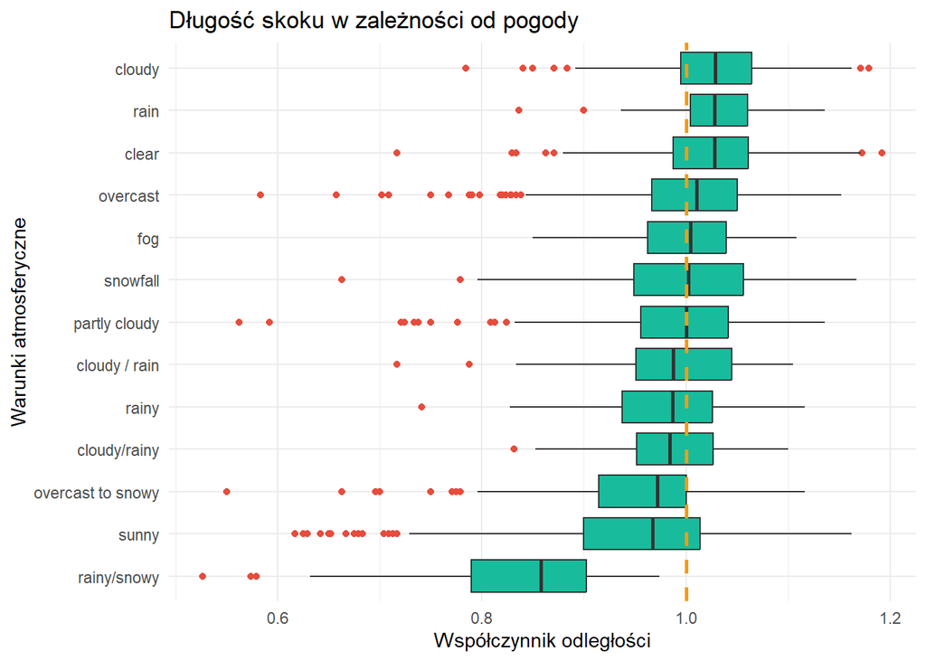

```r
ostateczne_dane %>%
  group_by(weather_type) %>%
  filter(n() > 50) %>%
  ggplot() +
  geom_boxplot(aes(reorder(x=weather_type, dist_prop, FUN=median), y=dist_prop), fill="#18bc9c", outlier.color ="#e74c3c" ) +
  geom_hline(yintercept = 1, linetype="dashed", col='#f39c12', linewidth = 1) +
  labs(title="Długość skoku w zależności od pogody",
       x="Warunki atmosferyczne",
       y="Współczynnik odległości") +
  coord_flip() +
  theme_minimal()
```

```r
ostateczne_dane %>%
  group_by(weather_type) %>%
  summarise(mediana = median(dist_prop), srednia = mean(dist_prop), count = n()) %>%
arrange(desc(mediana))
```

```
## # A tibble: 17 × 4
##    weather_type      mediana srednia count
##    <fct>               <dbl>   <dbl> <int>
##  1 snowfall / cloudy   1.05    1.04     50
##  2 overcast, rainy     1.04    1.03     30
##  3 cloudy              1.03    1.03    734
##  4 rain                1.03    1.03    142
##  5 clear               1.03    1.02    271
##  6 lightly rain        1.02    1.03     44
##  7 overcast            1.01    1.00   1178
##  8 snowy               1.01    1.00     30
##  9 fog                 1.00    1.00     51
## 10 snowfall            1.00    0.998   194
## 11 partly cloudy       1       0.996   989
## 12 cloudy / rain       0.988   0.988   100
## 13 rainy               0.987   0.979    74
## 14 cloudy/rainy        0.984   0.983    52
## 15 overcast to snowy   0.972   0.949   151
## 16 sunny               0.967   0.947   488
## 17 rainy/snowy         0.858   0.834    71
```

**wnioski:** Filtruję wstępnie dane, pozbywam się grup z licznością n<50, aby nie zaburzyć sobie wykresu nieistotnym szumem. Widzę, że **dłuższe skoki były oddawane kiedy było pochmurnie, padał deszcz lub kiedy było czyste niebo**. Krótsze skoki były oddawane szczególnie, kiedy występował deszcz ze śniegiem. **Dla porównania tworzę tabelę, w której już widzę inne wyniki, lecz jest to związane ze zbyt małą licznością grup**.

## 4.9 Wpływ konkretnych warunków pogodowanych na długość skoku

W moich danych mam kilka zmiennych opisujących już dokładniejsze warunki atmosferyczne. Są to: `wind` - prędkość wiatru w metrach na sekundę (dodatnia - wiatr pod narty, ujemna - wiatr z tyłu skoczni), `humid` - wilgotność powietrza, `snow_temperature` - temperatura śniegu na najeździe, `air_temperature` - temperatura powietrza. Mam kolejny problem - wartości zmiennych `humid`, `snow_temperature` i `air_temperature` są średnimi wartościami, dla danego konkursu, a nie dla konkretnego skoku. Zmienna `wind` już jest dla każdego skoku. Dlatego wykonam dwa porównania, jedną dla wiatru i drugą dla pozostałych zmiennych, mając na uwadze, że ich wartości są uśrednione. Do korelacji w tym i kolejnym podpunkcie używam metody spearmana - rozkład zmiennej “dist_prop” nie jest normalny.

```r
cor1=cor(ostateczne_dane[,c("dist_prop", "wind")], method="spearman")
round(cor1, 2)
```

```
##           dist_prop wind
## dist_prop      1.00 0.22
## wind           0.22 1.00
```

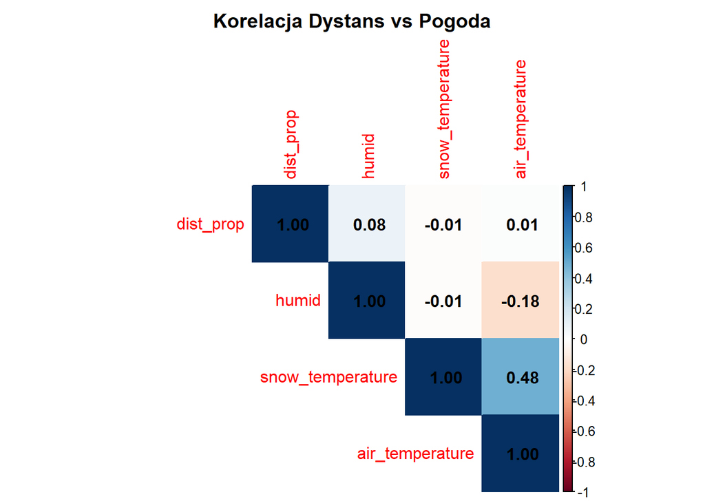

```r
cor2=cor(ostateczne_dane[,c("dist_prop", "humid", "snow_temperature", "air_temperature")], method = "spearman")

corrplot(cor2,
         method = "color",
         type = "upper",
         title = "Korelacja Dystans vs Pogoda",
         mar = c(0,0,2,0),
         addCoef.col = "black"
         )
```

**wnioski:** Z policzonej korelacji dla zmiennej `wind` widzimy, że istnieje mała korelacja dodatnia - nie jest ona na tyle duża, aby istniał jakiś silniejszy związek. Dla zmiennych `humid`, `snow_temperature` i `air_temperature` korelacja jest bliska 0 - związki tym bardziej nie istnieją, może to być spowodowane tym, że korzystam z danych uśrednionych, bo inne nie występowały w oryginalnym zbiorze.

## 4.10 Długość skoku, a statystyki techniczne.

Po analizie warunków pogodowych, nie wyszło nam wiele zależności, w stosunku do długości oddanego skoku. Może patrząc od strony technicznej otrzymamy jakieś lepsze związki. Będziemy brali pod uwagę zmienne `speed` - prędkość na progu `note_points` - sumaryczna ocena sędziów, `jump_gate` - belka, z której skakał zawodnik. Badane zmienne znowu będziemy porównywać do długości lotu w stosunku do punktu k na danej skoczni.

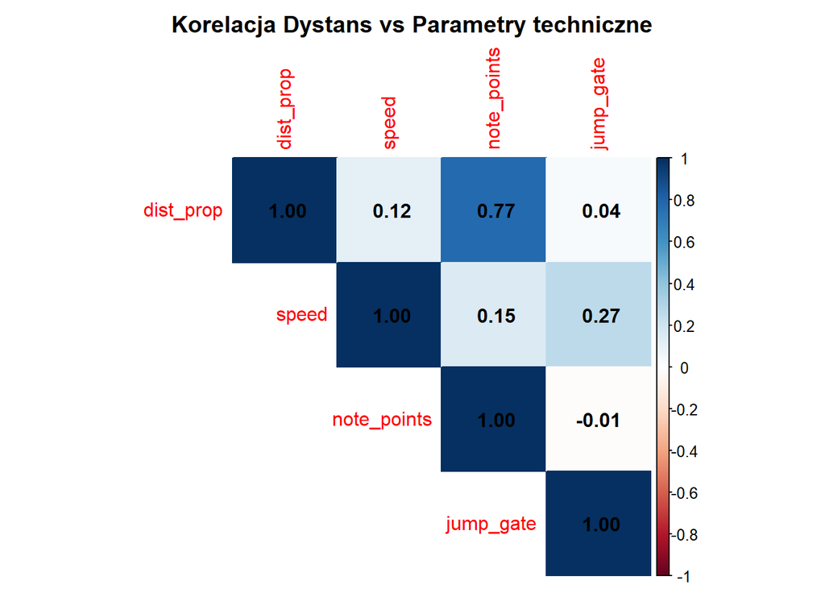

```r
cor3=cor(ostateczne_dane[,c("dist_prop", "speed", "note_points", "jump_gate")], method="spearman")
corrplot(cor3,
         method = "color",
         type = "upper",
         title = "Korelacja Dystans vs Parametry techniczne",
         mar = c(0,0,2,0),
         addCoef.col = "black"
         )
```

**wnioski:** Z wykresu możemy odczytać, że wysoką dodatnią korelację w porównaniu z odległością ma `note_points` - z tego wynika, że sędziowie lepiej oceniają dłuższe skoki, co było spodziewane. Jednak pozostałe zmienne `speed` i `jump_gate` nie mają znaczącego związku z długością skoku. Logicznie nie ma to sensu, gdyż czy to prędkość na progu czy belka powinny wpływać na długość skoku, jednakże większość skoków jest oddawana na podobnym poziomie - różnice nie są na tyle duże, aby związek ten wyszedł istotnie duży.

# 5 Podsumowanie